# Regresiones V2

Bryan Castillo

24 de agosto de 2021

## 1. Análisis exploratorio-gráfico de algunas variables

A continuación pueden ver el análisis exploratorio gráfico de algunas variables con la huella de carbono per-cápita por hogar, las variables independientes en este caso son:

- Grupo Socio Económico (GSE)
- Tenencia de auto
- Anda más en bicicleta
- Conoce la calidad del aire de su ciudad
- Ha bajado el ingreso promedio del hogar
- Densidad del barrio
- Distancia (network) al cenetro
- Huella de carbono y ciudad
- Viaja a comprar alimentos

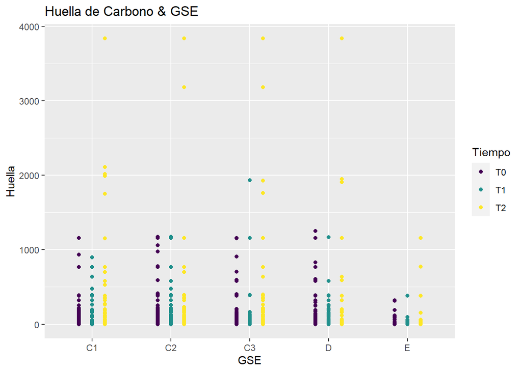

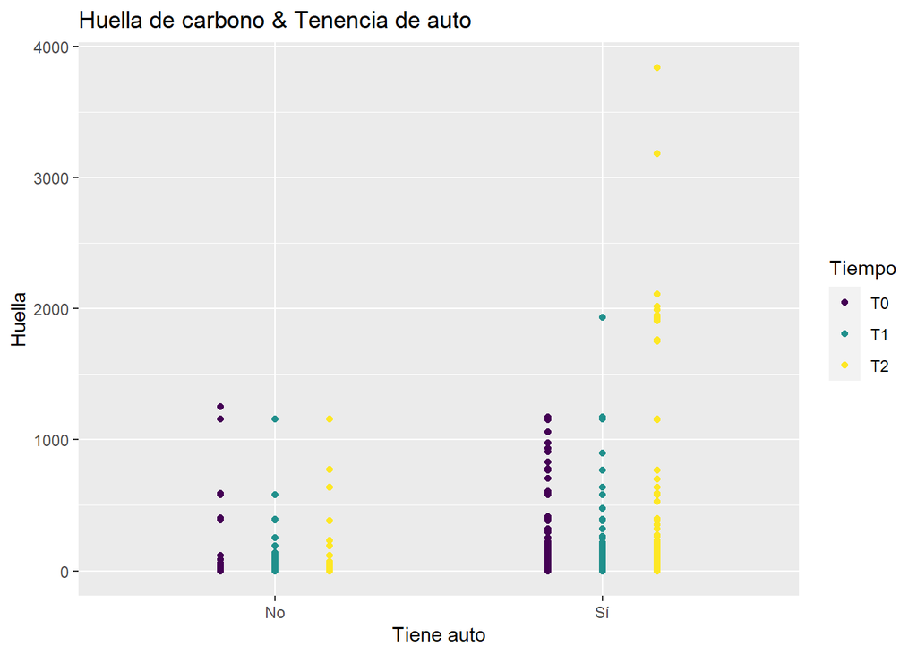

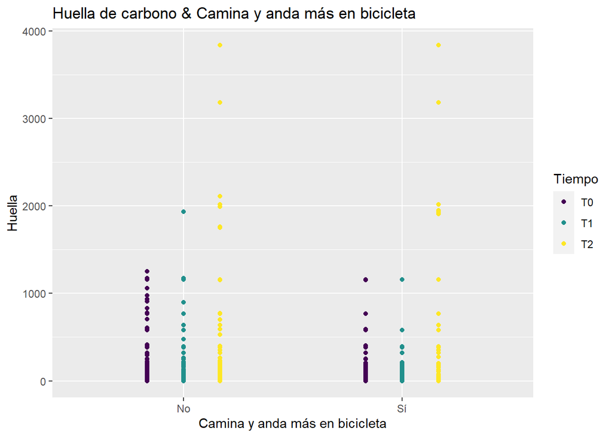

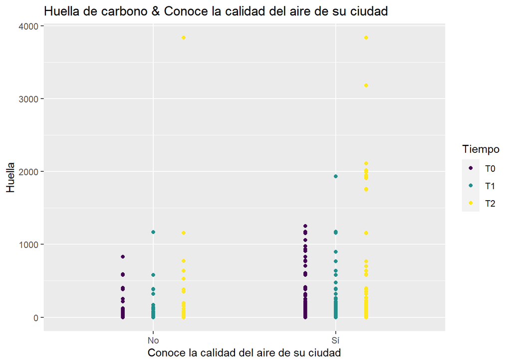

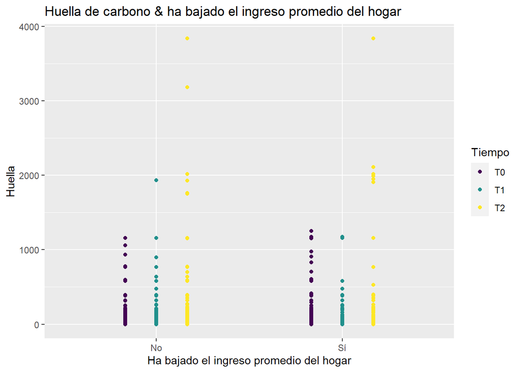

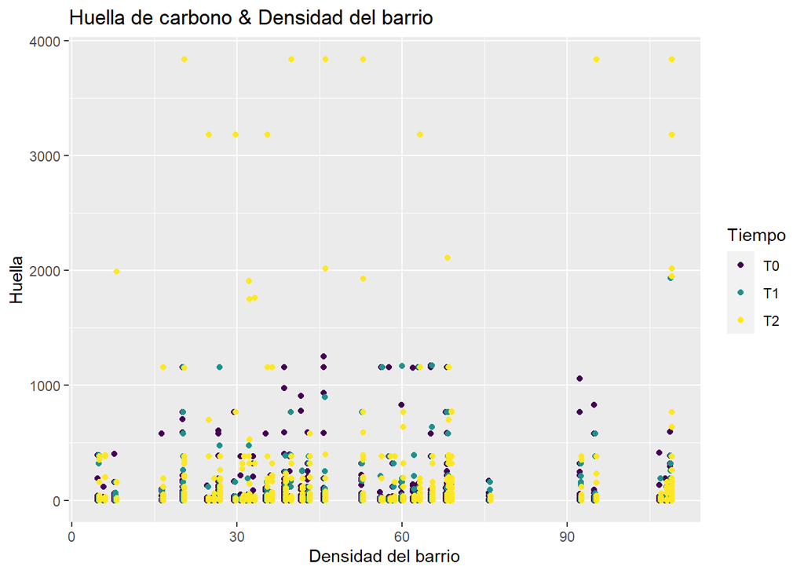

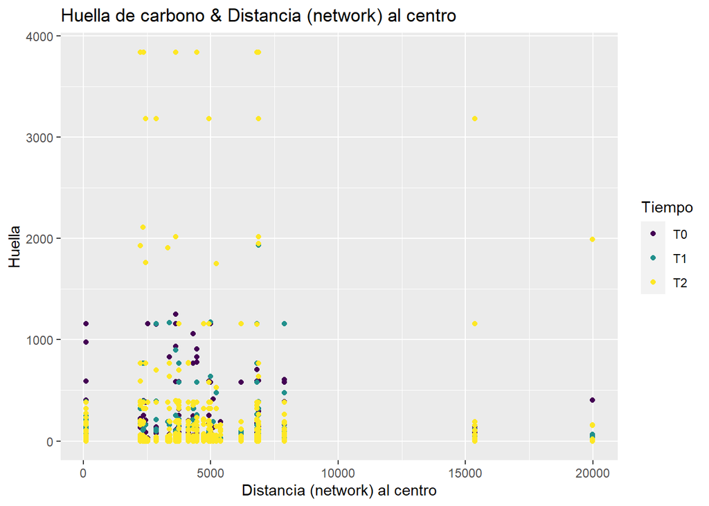

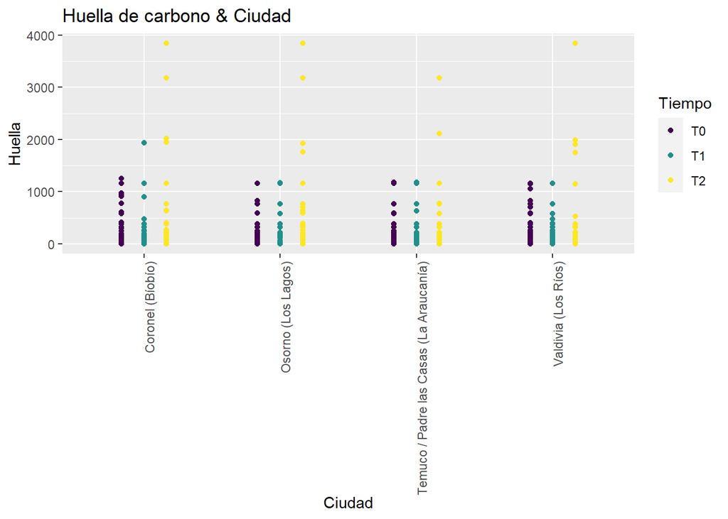

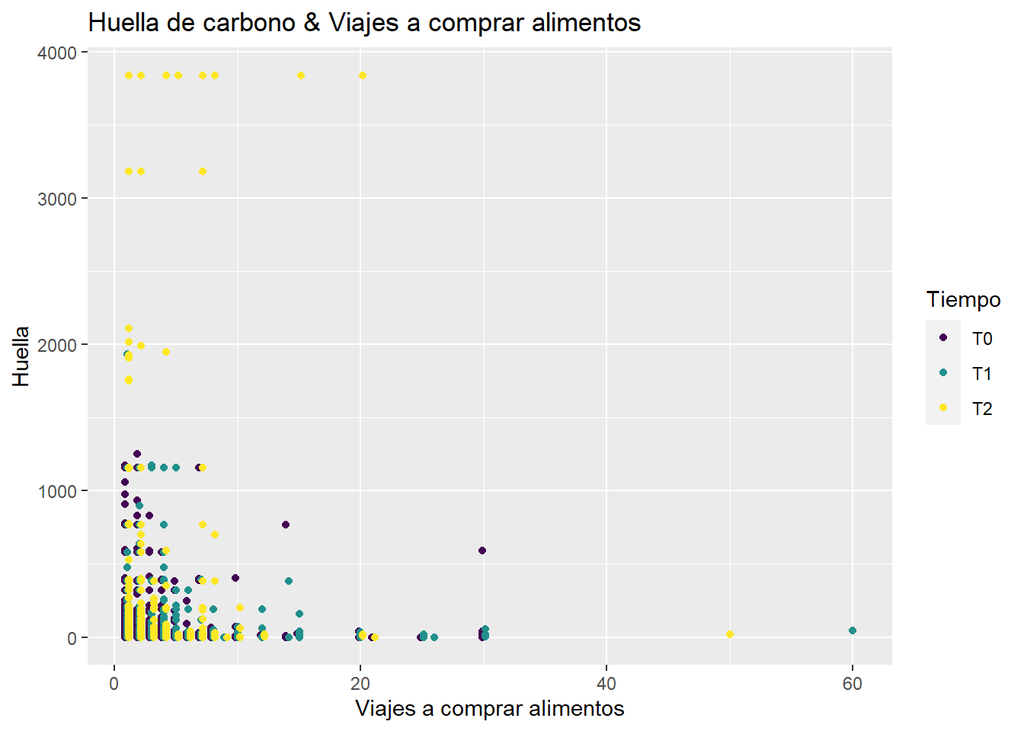

## 2. Corriendo modelos lineales

Se corren modelos lineales con 19 variables independientes en cada contexto temporal (T0-T1-T2). El resultado de cada modelo consta de cuatro columnas que resumen los siguientes valores por cada coeficiente o variable independiente: *Coefficients, Estimate, Std. Error, t value, Pr(>|t|)*. El nombre de las variables independientes categóricas puede ser visto, al igual que las numéricas, en la columna *Coefficients* pero esta vez precedido por *as.factor(*, ya que son variables factores o categóricas.

La cantidad de asteríscos ‘*’ indica el nivel de significancia de cada variable en el modelo, tal como se resume a continuación:

**Si significancia:**

- 0 = ***
- 0.001= **
- 0.01= *
- 0.05= .
- 0.1= ’ ’

Por último cada cuadro muestra algunos estadísticos del modelo, tales como:

- Residual standard error
- Multiple R-squared
- Adjusted R-squared
- F-statistic
- p-value

#### Modelo lineal en T0:

```
##
## Call:
## lm(formula = footPrintPerT0 ~ as.factor(tieneAuto) + as.factor(aislaVivienda) +
##     as.factor(cambiaCalefactores) + as.factor(masBiciMasCamina) +
##     as.factor(alimentacionSaludable) + as.factor(hogarRecicla) +
##     as.factor(conoceContaminacion) + as.factor(`F0_Coronel (Bíobío)`) +
##     as.factor(`F0_Osorno (Los Lagos)`) + as.factor(`F0_Temuco/PadreLasCasas`) +
##     as.factor(GSE_C1) + as.factor(GSE_C2) + as.factor(GSE_C3) +
##     as.factor(GSE_D) + as.factor(bajaIngreso) + `Densidad del barrio (hab)` +
##     `Distancia al centro Network` + desplazaAlimentoT0 + cantidadPersonas,
##     data = bd1hogar)
##
## Residuals:
##     Min      1Q  Median      3Q     Max
## -124.08  -59.83  -42.67  -16.96 1157.36
##
## Coefficients:
##                                         Estimate Std. Error t value Pr(>|t|)
## (Intercept)                            30.292542  33.695336   0.899    0.369
## as.factor(tieneAuto)Sí                 13.259433  12.807736   1.035    0.301
## as.factor(aislaVivienda)Sí             11.030462  11.322621   0.974    0.330
## as.factor(cambiaCalefactores)Sí       -23.293029  16.403022  -1.420    0.156
## as.factor(masBiciMasCamina)Sí         -12.174800  10.899640  -1.117    0.264
## as.factor(alimentacionSaludable)Sí     -7.748869  10.317172  -0.751    0.453
## as.factor(hogarRecicla)Sí               1.031225  10.771371   0.096    0.924
## as.factor(conoceContaminacion)Sí        6.430612  16.487922   0.390    0.697
## as.factor(`F0_Coronel (Bíobío)`)1      20.740227  15.193866   1.365    0.173
## as.factor(`F0_Osorno (Los Lagos)`)1    -5.123638  15.062095  -0.340    0.734
## as.factor(`F0_Temuco/PadreLasCasas`)1 -12.072339  15.075341  -0.801    0.423
## as.factor(GSE_C1)1                     21.978400  27.188250   0.808    0.419
## as.factor(GSE_C2)1                     25.711007  25.599217   1.004    0.315
## as.factor(GSE_C3)1                     37.314764  25.680296   1.453    0.146
## as.factor(GSE_D)1                      30.698700  26.139829   1.174    0.240
## as.factor(bajaIngreso)Sí                0.892269  10.754127   0.083    0.934
## `Densidad del barrio (hab)`             0.057263   0.200949   0.285    0.776
## `Distancia al centro Network`           0.002452   0.001914   1.281    0.201
## desplazaAlimentoT0                      0.095274   0.254431   0.374    0.708
## cantidadPersonas                       -9.580256   6.526750  -1.468    0.142
##
## Residual standard error: 169.3 on 1115 degrees of freedom
##   (65 observations deleted due to missingness)
## Multiple R-squared:  0.01829,    Adjusted R-squared:  0.00156
## F-statistic: 1.093 on 19 and 1115 DF,  p-value: 0.3515
```

#### Modelo lineal en T1:

```
##
## Call:
## lm(formula = footPrintPerT1 ~ as.factor(tieneAuto) + as.factor(aislaVivienda) +
##     as.factor(cambiaCalefactores) + as.factor(masBiciMasCamina) +
##     as.factor(alimentacionSaludable) + as.factor(hogarRecicla) +
##     as.factor(conoceContaminacion) + as.factor(`F0_Coronel (Bíobío)`) +
##     as.factor(`F0_Osorno (Los Lagos)`) + as.factor(`F0_Temuco/PadreLasCasas`) +
##     as.factor(GSE_C1) + as.factor(GSE_C2) + as.factor(GSE_C3) +
##     as.factor(GSE_D) + as.factor(bajaIngreso) + `Densidad del barrio (hab)` +
##     `Distancia al centro Network` + desplazaAlimentoT1 + cantidadPersonas,
##     data = bd1hogar)
##
## Residuals:
##     Min      1Q  Median      3Q     Max
## -102.54  -45.77  -27.63  -10.71 1846.17
##
## Coefficients:
##                                         Estimate Std. Error t value Pr(>|t|)
## (Intercept)                            29.283513  27.679747   1.058  0.29031
## as.factor(tieneAuto)Sí                 10.774657  10.566995   1.020  0.30811
## as.factor(aislaVivienda)Sí             -2.130411   9.326448  -0.228  0.81936
## as.factor(cambiaCalefactores)Sí        -4.696215  13.525896  -0.347  0.72851
## as.factor(masBiciMasCamina)Sí          -7.033258   8.964678  -0.785  0.43288
## as.factor(alimentacionSaludable)Sí     -0.177843   8.508295  -0.021  0.98333
## as.factor(hogarRecicla)Sí              -7.086406   8.878485  -0.798  0.42495
## as.factor(conoceContaminacion)Sí       -2.686366  13.573563  -0.198  0.84315
## as.factor(`F0_Coronel (Bíobío)`)1       2.481546  12.524094   0.198  0.84297
## as.factor(`F0_Osorno (Los Lagos)`)1     4.734790  12.425854   0.381  0.70324
## as.factor(`F0_Temuco/PadreLasCasas`)1  -8.867498  12.414967  -0.714  0.47522
## as.factor(GSE_C1)1                     22.013691  22.392018   0.983  0.32577
## as.factor(GSE_C2)1                     19.075280  21.062138   0.906  0.36531
## as.factor(GSE_C3)1                     21.101621  21.154568   0.997  0.31874
## as.factor(GSE_D)1                      21.944518  21.507198   1.020  0.30779
## as.factor(bajaIngreso)Sí              -24.296844   8.864723  -2.741  0.00623 **
## `Densidad del barrio (hab)`             0.174880   0.165597   1.056  0.29117
## `Distancia al centro Network`           0.003513   0.001578   2.226  0.02621 *
## desplazaAlimentoT1                     -0.367358   0.267562  -1.373  0.17003
## cantidadPersonas                       -6.230347   5.379274  -1.158  0.24703
## ---
## Signif. codes:  0 '***' 0.001 '**' 0.01 '*' 0.05 '.' 0.1 ' ' 1
##
## Residual standard error: 139.6 on 1115 degrees of freedom
##   (65 observations deleted due to missingness)
## Multiple R-squared:  0.02269,    Adjusted R-squared:  0.006038
## F-statistic: 1.363 on 19 and 1115 DF,  p-value: 0.1362
```

#### Modelo lineal en T2:

```
##
## Call:
## lm(formula = footPrintPerT2 ~ as.factor(tieneAuto) + as.factor(aislaVivienda) +
##     as.factor(cambiaCalefactores) + as.factor(masBiciMasCamina) +
##     as.factor(alimentacionSaludable) + as.factor(hogarRecicla) +
##     as.factor(conoceContaminacion) + as.factor(`F0_Coronel (Bíobío)`) +
##     as.factor(`F0_Osorno (Los Lagos)`) + as.factor(`F0_Temuco/PadreLasCasas`) +
##     as.factor(GSE_C1) + as.factor(GSE_C2) + as.factor(GSE_C3) +
##     as.factor(GSE_D) + as.factor(bajaIngreso) + `Densidad del barrio (hab)` +
##     `Distancia al centro Network` + desplazaAlimentoT2 + cantidadPersonas,
##     data = bd2hogar)
##
## Residuals:
##    Min     1Q Median     3Q    Max
## -448.5 -172.1  -98.9    1.7 3700.8
##
## Coefficients:
##                                         Estimate Std. Error t value Pr(>|t|)
## (Intercept)                           101.973252 116.467080   0.876  0.38151
## as.factor(tieneAuto)Sí                143.983778  44.516063   3.234  0.00126 **
## as.factor(aislaVivienda)Sí            -21.266103  39.742536  -0.535  0.59272
## as.factor(cambiaCalefactores)Sí       -64.217664  56.746935  -1.132  0.25809
## as.factor(masBiciMasCamina)Sí          -4.972752  35.216731  -0.141  0.88774
## as.factor(alimentacionSaludable)Sí     19.571763  34.616421   0.565  0.57195
## as.factor(hogarRecicla)Sí             -22.314022  34.937243  -0.639  0.52319
## as.factor(conoceContaminacion)Sí       14.225878  51.980344   0.274  0.78440
## as.factor(`F0_Coronel (Bíobío)`)1     -11.714829  49.065189  -0.239  0.81135
## as.factor(`F0_Osorno (Los Lagos)`)1    14.137535  49.128187   0.288  0.77359
## as.factor(`F0_Temuco/PadreLasCasas`)1 -57.954457  49.640114  -1.167  0.24333
## as.factor(GSE_C1)1                     35.906775  96.850298   0.371  0.71092
## as.factor(GSE_C2)1                    -71.308329  91.767138  -0.777  0.43733
## as.factor(GSE_C3)1                     24.206119  92.065599   0.263  0.79267
## as.factor(GSE_D)1                     -33.224869  94.193759  -0.353  0.72438
## as.factor(bajaIngreso)Sí              -70.266317  34.293692  -2.049  0.04076 *
## `Densidad del barrio (hab)`             0.270227   0.647011   0.418  0.67630
## `Distancia al centro Network`           0.007443   0.006013   1.238  0.21615
## desplazaAlimentoT2                      0.800923   1.275447   0.628  0.53020
## cantidadPersonas                      -29.586111  28.505074  -1.038  0.29959
## ---
## Signif. codes:  0 '***' 0.001 '**' 0.01 '*' 0.05 '.' 0.1 ' ' 1
##
## Residual standard error: 494.8 on 883 degrees of freedom
##   (297 observations deleted due to missingness)
## Multiple R-squared:  0.03603,    Adjusted R-squared:  0.01529
## F-statistic: 1.737 on 19 and 883 DF,  p-value: 0.02595
```